# Visual R Markdown in R Markdown

Thomas Mock

9/23/2020

# Intro

Table 1 - Links to RStudio 1.4 Preview

| Platform | Download | Size |
| --- | --- | --- |
| Windows 10/8/7 | RStudio-1.4.861.exe | 157M |
| MacOS 10.13+ | RStudio-1.4.861.dmg | 154M |
| Ubuntu 18/Debian 10 | rstudio-1.4.861-amd64.deb | 115M |
| Fedora 28/Red Hat 8 | rstudio-1.4.861-x86_64.rpm | 132M |

[Full guide](https://rstudio.github.io/visual-markdown-editing/#/)

### Enabling Visual Mode

Markdown documents can be edited in either source or visual mode. To switch into visual mode for a given document, use the button at the top-right of the document toolbar (or alternatively the `⌘+⇧+F12` keyboard shortcut):

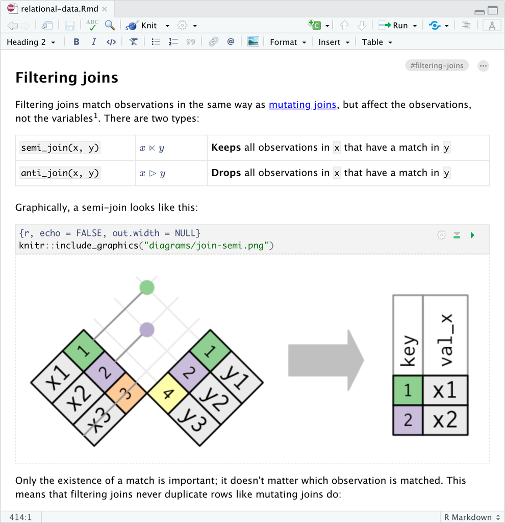

| Command | Keyboard Shortcut | Markdown Shortcut |
| --- | --- | --- |
| Bold | `⌘ B` | `**bold**` |
| Italic | `⌘ I` | `*italic*` |
| Code | `⌘ D` | `` `code` `` |
| Link | `⌘ K` | `<href>` |
| Heading 1 | `⌥⌘ 1` | `#` |
| Heading 2 | `⌥⌘ 2` | `##` |
| Heading 3 | `⌥⌘ 3` | `###` |
| R Code Chunk | `⌥⌘ I` | `` ```{r} `` |

### Insert Anything

You can also use the catch-all `⌘/` shortcut to insert just about anything. Just execute the shortcut then type what you want to insert. For example:

Use the `bullet`

- Output

Or `numbered`

1. Number list!

Here’s a link - how to turn into an image? Here’s a link: `https://rstudio.github.io/visual-markdown-editing/images/visual-editing-omni-list.png`

### Editor Toolbar

The editor toolbar includes buttons for the most commonly used formatting commands:

[figure not shown]

Additional commands are available on the **Format**, **Insert**, and **Table** menus:

### Format

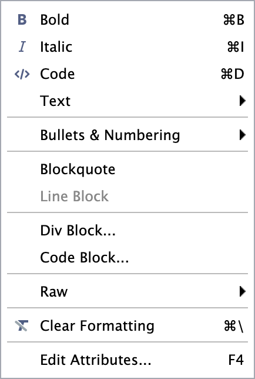

### Insert

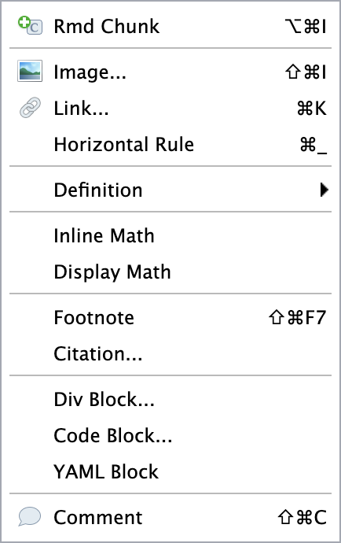

### Table

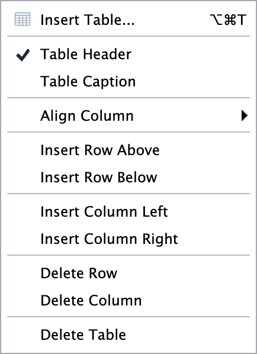

# Technical Writing

## Equations

LaTeX equations are authored using standard Pandoc markdown syntax (the editor will automatically recognize the syntax and treat the equation as math). When you aren’t directly editing an equation it will appear as rendered math:

$$P(E) = {n \choose k} p^k (2-p)^{n-k}$$

[figure not shown]

### Footnotes

You can include footnotes using the **Insert -> Footnote** command (or the `⇧ ⌘ F7` keyboard shortcut). Footnote editing occurs in a pane immediately below the main document:[^1] <- **NOTE THE FOOTMARK**

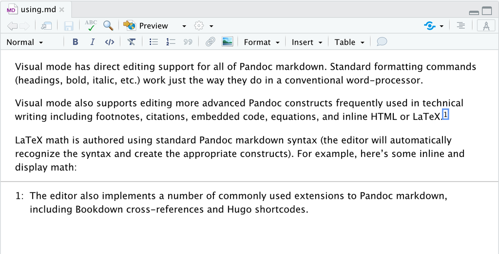

# Bibliographies

R Markdown supports bibliographies in a wide variety of formats including BibTeX and CSL. Add a bibliography to your document using the `bibliography` YAML metadata field. For example:

```
---
title: "My Document"
bibliography: references.bib
link-citations: true
---
```

## Inserting Citations

You insert citations by either using the **Insert -> Citation** command or by using markdown syntax directly (e.g. `[@cite]`).

Citations go inside square brackets and are separated by semicolons. Each citation must have a key, composed of ‘@’ + the citation identifier from the database, and may optionally have a prefix, a locator, and a suffix. The citation key must begin with a letter, digit, or `_`, and may contain alphanumerics, `_`, and internal punctuation characters (`:.#$%&-+?<>~/`). Here are some examples:

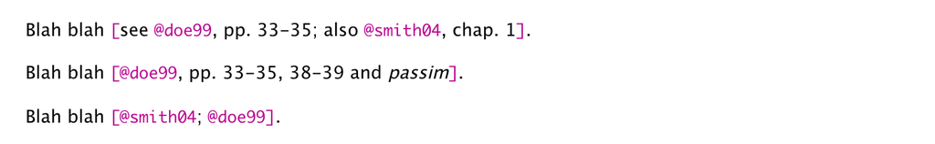

(Rottman-Sagebiel et al. 2018)

#### **DEMO OF CITATION WITH INSERT**

## Embedded Code

Source code which you include in an R Markdown document can either by for display only or can be executed by knitr as part of rendering. Code can furthermore be either inline or block (e.g. an Rmd code chunk).

### Displaying Code

To display but not execute code, either use the **Insert -> Code Block** menu item, or start a new line and type either:

1. `` ``` `` (for a plain code block); or
2. `` ```<lang> `` (where <lang> is a language) for a code block with syntax highlighting.

Then press the **Enter** key. To display code inline, simply surround text with backticks (`` `code` ``), or use the **Format -> Code** menu item.

```
library(tidyverse)
library(palmerpenguins)

penguins %>%
  ggplot(aes(x = body_weight_g, y = flipper_length_mm, color = species)) +
  geom_point()
```

### Code Chunks

To insert an executable code chunk, use the **Insert -> Code Chunk** menu item, or start a new line and type:

`` ```{r} ``

Then press the **Enter** key. Note that `r` could be another language supported by knitr (e.g. `python` or `sql`) and you can also include a chunk label and other chunk options.

To include inline R code, you just create normal inline code (e.g. by using backticks or the ⌘ D shortcut) but preface it with `r`. For example, this inline code will be executed by knitr: `2020-09-23`. Note that when the code displays in visual mode it won’t have the backticks (but they will still appear in source mode).

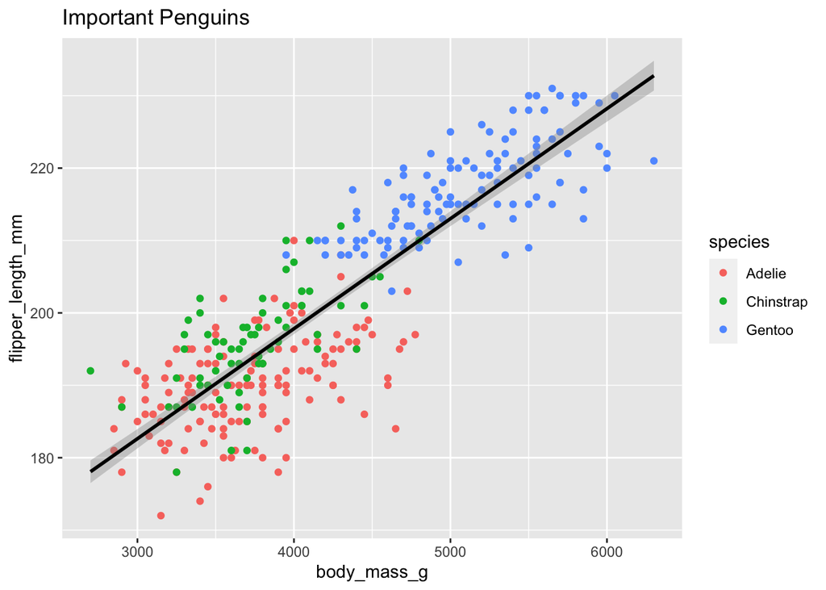

```r
penguins %>%
  na.omit() %>%
  ggplot(aes(x = body_mass_g, y = flipper_length_mm)) +
  geom_point(aes(color = species)) +
  labs(title = "Important Penguins") +
  geom_smooth(method = "lm", color = "black")
```

Rottman-Sagebiel, Rebecca, Nicole Cupples, Chen Pin Wang, Seth Cope, Stephanie Pastewait, Hanna Braden, Daniel MacCarthy, et al. 2018. “A Pharmacist-Led Transitional Care Program to Reduce Hospital Readmissions in Older Adults.” *Federal Practitioner* 35 (12): 42–50. https://www.ncbi.nlm.nih.gov/pmc/articles/PMC6366589/.

[^1]: Very fancy footnote to this portion